# My SpotifyR report

Author

Monica Garcia

# Let’s talk about the queen of Spain (Rosalía)

## Who is Rosalía?

Spanish singer, songwriter, and producer known for blending traditional flamenco with modern urban music.

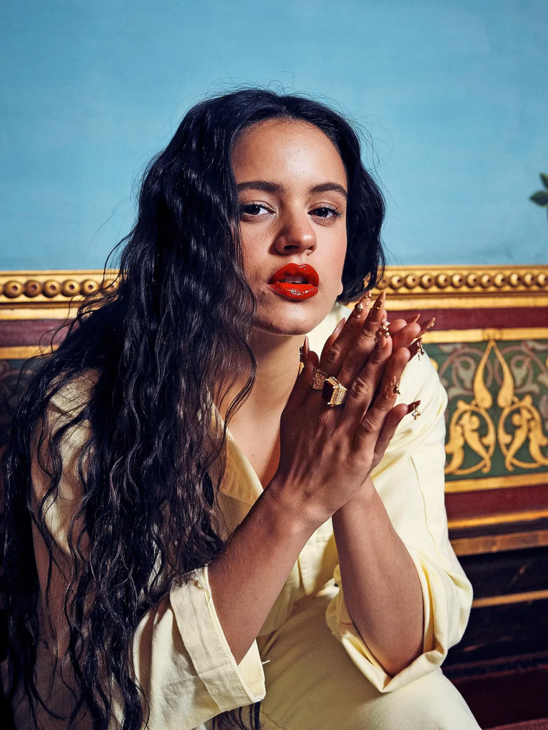

## Her albums

**Los Ángeles (2017)**

**El Mal Querer (2018)**

**MOTOMAMI (2022)**

[figure not shown]

[figure not shown]

[figure not shown]

Melancholic

Tragic

Experimental

## My favourite album: *El Mal Querer*

- Narrates the emotional and psychological journey of a woman trapped in a toxic relationship.
- Each song is a chapter of the story.
- It was her bachelor’s thesis for her music degree with a specialization in flamenco.

> “It traps you without you realizing it

> You realize it when you get out

> You think, how did I get here?”

> - **ROSALÍA** in *(C*a*p.6: Clausura)*

# Data analysis

## Data source

```r
# Packages
library(ggplot2)
library(dplyr)

# Import data into df
df <- read.csv("data/ROSALÍA.csv")
```

## Glace of the data frame

```r
# Slice 5 random record in the dataframe
df |> dplyr::slice_sample(n=5) |> knitr::kable(digits = 2)
```

| artist_name | track_name | track_number | album_name | album_release_year | album_release_date | valence | energy | danceability | loudness | tempo | speechiness | instrumentalness | liveness | key_name | mode_name | key_mode | duration_ms |
| --- | --- | --- | --- | --- | --- | --- | --- | --- | --- | --- | --- | --- | --- | --- | --- | --- | --- |
| ROSALÍA | MALAMENTE - Cap.1: Augurio | 1 | El Mal Querer | 2018 | 2018-11-02 | 0.53 | 0.48 | 0.89 | -4.78 | 97.97 | 0.09 | 0.02 | 0.08 | C | minor | C minor | 150027 |
| ROSALÍA | LA KILIÉ | 21 | MOTOMAMI + | 2022 | 2022-09-09 | 0.90 | 0.51 | 0.62 | -7.08 | 181.88 | 0.63 | 0.01 | 0.08 | F# | minor | F# minor | 131087 |
| ROSALÍA | LA COMBI VERSACE | 14 | MOTOMAMI + | 2022 | 2022-09-09 | 0.45 | 0.48 | 0.86 | -5.84 | 90.97 | 0.54 | 0.00 | 0.10 | F | minor | F minor | 160296 |
| ROSALÍA | COMO UN G | 15 | MOTOMAMI + | 2022 | 2022-09-09 | 0.22 | 0.13 | 0.49 | -14.32 | 63.82 | 0.05 | 0.00 | 0.22 | G | minor | G minor | 262104 |
| ROSALÍA | El Redentor | 11 | Los Ángeles | 2017 | 2017-02-10 | 0.21 | 0.37 | 0.26 | -8.02 | 95.22 | 0.03 | 0.00 | 0.09 | F | minor | F minor | 181481 |

# Data preparation

```r
# Remove records with the same track names
df <- df|> distinct(track_name, .keep_all = TRUE)
# Filter out track names that include "Live at" or "Live Acoustic"
df <- df |> filter(!grepl("Live at|Live Acoustic", track_name))
# Change the data type of album_name from numeric into character
df$album_name <- as.character(df$album_name)
# Order the albums by release year
df$album_name <- factor(df$album_name, levels = unique(df$album_name[order(df$album_release_year)]))
# Add album as variable
el_mal_querer <- df |> filter(album_name == "El Mal Querer") |> arrange(track_number)
```

# Album analysis

## Valence

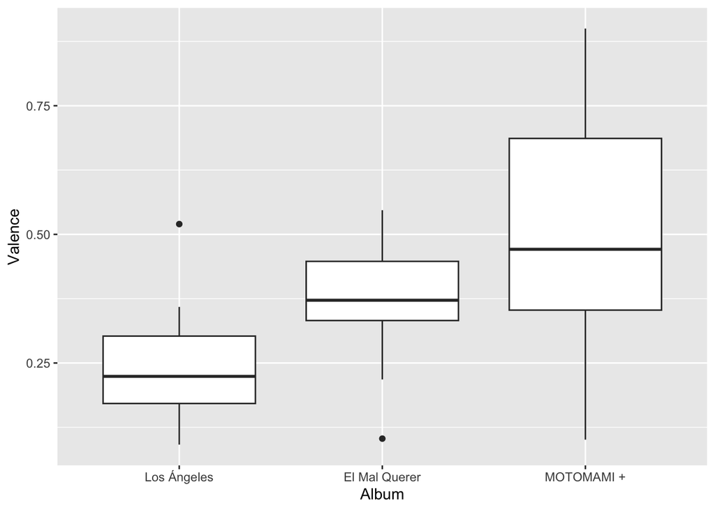

```r
# Change album name from character to factor before plotting
df$album_name <- as.factor(df$album_name)
# Plot a bosplot
ggplot(df, aes(x=album_name, y=valence))+
    geom_boxplot()+
    labs(x="Album", y="Valence")
```

## Valance vs Energy

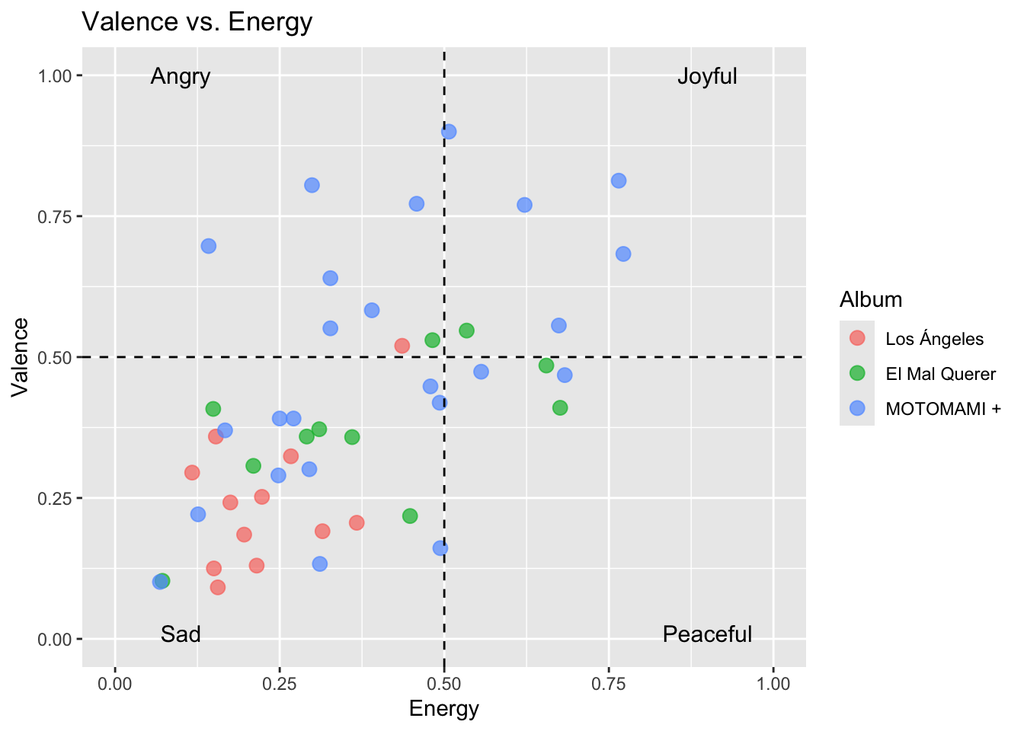

```r
ggplot(df, aes(x = energy, y = valence, color = album_name)) +
  geom_point(size = 3, alpha = 0.7) +
  geom_vline(xintercept = 0.5, linetype = "dashed", color = "black") +  # Vertical line at x = 0.5
  geom_hline(yintercept = 0.5, linetype = "dashed", color = "black") +  # Horizontal line at y = 0.5
  annotate("text", x = 0.9, y = 1, label = "Joyful", size = 4) +
  annotate("text", x = 0.1, y = 1, label = "Angry", size = 4) +
  annotate("text", x = 0.1, y = 0.01, label = "Sad", size = 4) +
  annotate("text", x = 0.9, y = 0.01, label = "Peaceful", size = 4) +
  labs(title = "Valence vs. Energy",
       x = "Energy",
       y = "Valence",
       color = "Album") +
  xlim(0, 1) +
  ylim(0, 1)
```

## Speechiness

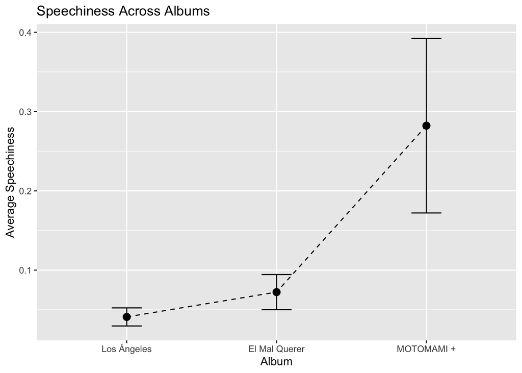

```r
library(ggplot2)
library(Hmisc)

ggplot(df, aes(x = album_name, y = speechiness, group = 1)) +
  stat_summary(fun = mean, geom = "point", size = 3) +  # Mean points
  stat_summary(fun.data = mean_cl_normal, geom = "errorbar", width = 0.2) +
  stat_summary(fun = mean, geom = "line", linetype = "dashed") +
  labs(title = "Speechiness Across Albums",
       x = "Album",
       y = "Average Speechiness")
```

### Rosalía’s Most Speechy Song

```r
df |> slice_max(speechiness, n=1) |> dplyr::select(track_name, album_name, speechiness) |> knitr::kable(digits = 2)
```

| track_name | album_name | speechiness |
| --- | --- | --- |
| Abcdefg | MOTOMAMI + | 0.95 |

[Abcdef](https://www.youtube.com/watch?v=8olELDQ2nDE)

[video not shown]

# *El Mal Querer* Analysis

| Track name: tittle + chapter nº + story event | Story event in English |
| --- | --- |
| «Malamente» (Cap.1: Augurio) | Omen |
| «Que no salga la luna» (Cap.2: Boda) | Marriage |
| «Pienso en tu mirá» (Cap.3: Celos) | Jealousy |
| «De aquí no sales» (Cap.4: Disputa) | Control |
| «Reniego» (Cap.5: Lamento) | Regret |
| «Preso» (Cap.6: Clausura) | Clousure |
| «Bagdad» (Cap.7: Liturgia) | Trapped |
| «Di mi nombre» (Cap.8: Éxtasis) | Extasis |
| «Nana» (Cap.9: Concepción) | Conception |
| «Maldición» (Cap.10: Cordura) | Sanity |
| «A ningún hombre» (Cap.11: Poder) | Empowerment |

## Valence

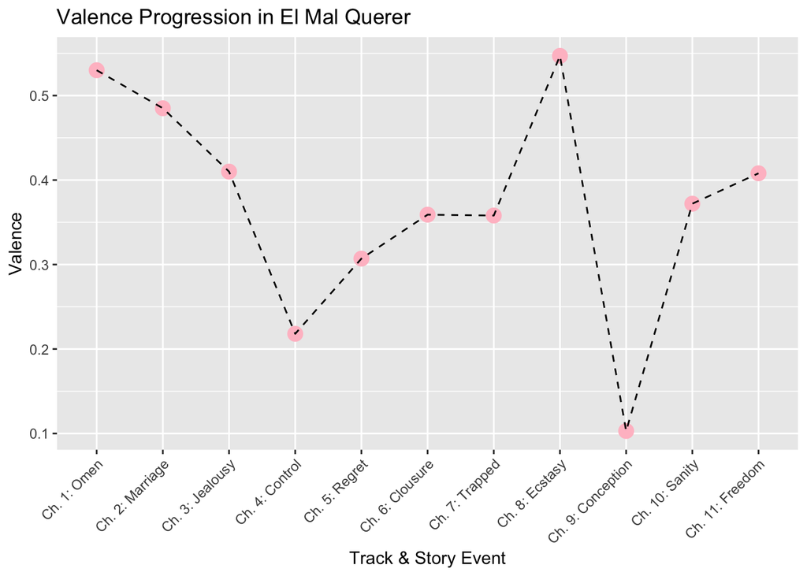

```r
# Define story events with chapter numbers
story_events <- c("Ch. 1: Omen", "Ch. 2: Marriage", "Ch. 3: Jealousy",
                  "Ch. 4: Control", "Ch. 5: Regret", "Ch. 6: Clousure",
                  "Ch. 7: Trapped", "Ch. 8: Ecstasy", "Ch. 9: Conception",
                  "Ch. 10: Sanity", "Ch. 11: Freedom")

#Plot valance progression of tracks
ggplot(el_mal_querer, aes(x=factor(track_number, levels=track_number, labels=story_events), y=valence)) +
    geom_point(color="pink", size=4) +
    geom_line(group=1, color="black", linetype="dashed") +
    labs(title="Valence Progression in El Mal Querer",
         x="Track & Story Event", y="Valence") +
    theme(axis.text.x = element_text(angle = 45, hjust = 1))
```

## Valence and Energy

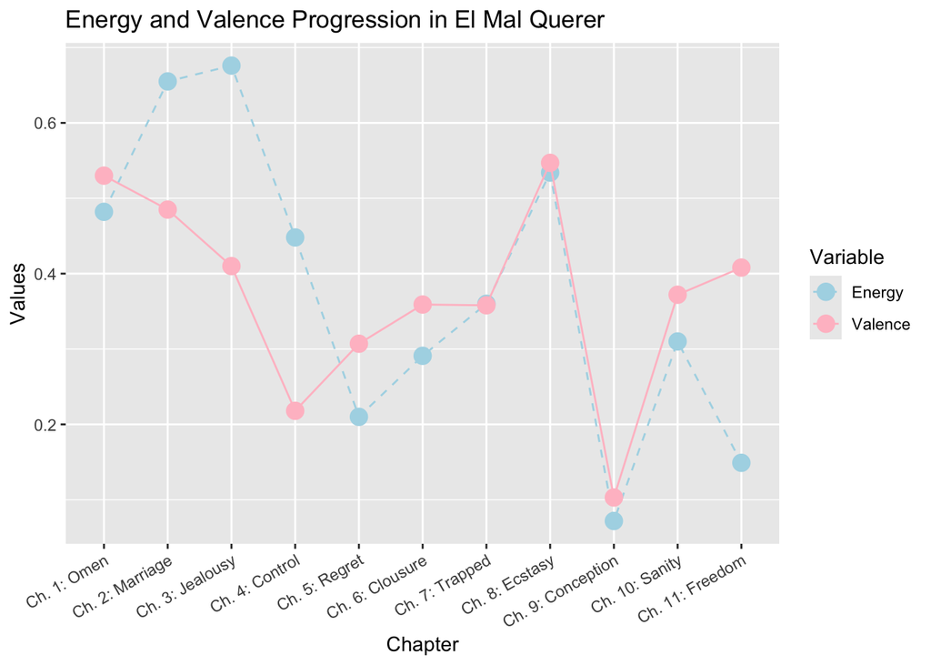

```r
el_mal_querer <- df |> filter(album_name == "El Mal Querer") |> arrange(track_number)

chapter_labels <- c("Ch. 1: Omen", "Ch. 2: Marriage", "Ch. 3: Jealousy",
                  "Ch. 4: Control", "Ch. 5: Regret", "Ch. 6: Clousure",
                  "Ch. 7: Trapped", "Ch. 8: Ecstasy", "Ch. 9: Conception",
                  "Ch. 10: Sanity", "Ch. 11: Freedom")

ggplot(el_mal_querer, aes(x = factor(track_number, levels = track_number))) +
    geom_line(aes(y = energy, group = 1, color = "Energy"), linetype = "dashed", size = 0.5) +
    geom_point(aes(y = energy, color = "Energy"), size = 4) +
    geom_line(aes(y = valence, group = 1, color = "Valence"), size = 0.5) +
    geom_point(aes(y = valence, color = "Valence"), size = 4) +
    labs(title = "Energy and Valence Progression in El Mal Querer",
         x = "Chapter",
         y = "Values",
         color = "Variable") +
    scale_x_discrete(labels = chapter_labels) +
    theme(axis.text.x = element_text(angle = 30, hjust = 1)) +
    scale_color_manual(values = c("Energy" = "lightblue", "Valence" = "pink"))
```

## How the data fits in narrative

These graphs illustrate how *El Mal Querer* portrays the **emotional journey of an abusive relationship:**

The begnning is very intense and passionate (high energy and valence).

Things slowly get worse and toxic (declining valence) and the passion fades out (low energy).

There is a fleeting honeymoon phase, where the abuser restores the initial ecstasy (high energy), creating momentary hope (high valence).

However, there is an inflection point (extreme low valence and energy) in Ch 9: Pregnancy**,** where she realizes that she needs to escape for her child.

Ultimately, she escapes, reaching Sanity (Ch 10) and Freedom (Ch 11). She is happier (increasing valence) but also more calm (decreasing energy).

Conclusion: *Prioritize tranquility and happiness over ecstasy! True love shouldn’t like a roller coaster :)*

## My favourite song from *El Mal Querer*:

### https://www.youtube.com/watch?v=uzmGZs1SeUM

[video not shown]